# Aprendizaje supervisado: modelos lineales

#### 2.6.1 Pregunta 1

> ¿De qué tipo es cada variable? Convierte las que consideres a cualis nominales y a cualis ordinales, y si hay alguna variable que deba ser lógica

```r
# id: en realidad esto tendría ser un factor (un texto) ya que no cuenta nada
# Cuantitativas: edad, horas_sueno
# Cualitativas nominales: genero, tipo_drogas
# Cuanitativas discretas: sesiones_terapia y actividad_fisica
# Cuantitativas discretas pero que deberíamos tratarlas como cualis ordinales
# ya que son escalas: ansiedad, depresión
# Binarias (cualis ordinales muy concretas): uso_drogas_recreativas
datos <-
  datos |>
  mutate("id" = as.character(id),
         "genero" = factor(genero), "tipo_drogas" = factor(tipo_drogas),
         "ansiedad" = factor(ansiedad, levels = as.character(1:10), ordered = TRUE),
         "depresion" = factor(depresion, levels = as.character(1:10), ordered = TRUE),
         "uso_drogas_recreativas" = (uso_drogas_recreativas == "Si"))
```

#### 2.6.2 Pregunta 2

> Calcula la tabla de frecuencias absolutas y relativas de género.

```r
tabla_freq_abs <- table(datos$genero)
tabla_freq_rel <- prop.table(tabla_freq_abs)
```

#### 2.6.3 Pregunta 3

> Calcula la media de las 4 variables cuantitativas que tenemos desagregado por género. Exporta dicho resumen en un `.csv`

```r
resumen <-
  datos |>
  drop_na(where(is.numeric)) |>
  summarise(across(where(is.numeric), mean), .by = genero)
write_csv(resumen, file = "./datos/resumen.csv")
```

#### 2.6.4 Pregunta 4

> Calcula la tabla de contigencia de las variables ansiedad vs genero. Calcula otra para ansiedad vs depresion. Usa `useNA = "always"` como argumento para incluir los `NA`

```r
tabla_freq_genero_ansiedad <- table(datos$genero, datos$ansiedad, useNA = "always")
tabla_freq_depresion_ansiedad <- table(datos$depresion, datos$ansiedad, useNA = "always")
```

#### 2.6.5 Pregunta 5

> Realiza un gráfico adecuado para la variable `edad`. Piensa como adaptarlo para tenerlo desagregado por `genero`.

```r
# Densidades
ggplot(datos) +
  geom_density(aes(x = edad), fill = "#459191", alpha = 0.4) +
  labs(x = "Edad (años)", y = "Densidad (frec relativa)") +
  theme_minimal()

library(ggridges)
ggplot(datos) +
  geom_density_ridges(aes(x = edad, y = genero, fill = genero), alpha = 0.4) +
  ggthemes::scale_fill_colorblind() +
  labs(x = "Edad (años)", y = "Sexo", fill = "Género") +
  theme_minimal()

# Histograma (mala idea con pocos datos)
ggplot(datos) +
  geom_histogram(aes(x = edad), bins = 15, fill = "#459191", alpha = 0.4) +
  labs(x = "Edad (años)", y = "Frec absoluta") +
  theme_minimal()
ggplot(datos) +
    geom_histogram(aes(x = edad, fill = genero), bins = 15, alpha = 0.25) +
    labs(x = "Edad (años)", y = "Frec absoluta") +
    theme_minimal()

# Boxplot
ggplot(datos) +
  geom_boxplot(aes(y = edad), fill = "#459191", alpha = 0.4,
               outlier.size = 3, outlier.alpha = 0.9,
               outlier.color = "#991293", outlier.shape = 18) +
  labs(y = "Edad") +
  theme_minimal()

ggplot(datos, aes(x = genero, y = edad, fill = genero, color = genero)) +
  geom_boxplot(alpha = 0.4, outlier.size = 3, outlier.alpha = 0.9,
               outlier.color = "#991293", outlier.shape = 18) +
  ggthemes::scale_color_colorblind() +
  ggthemes::scale_fill_colorblind() +
  guides(color = "none") +
  labs(x = "Género", y = "Edad", fill = "Género") +
  theme_minimal()
```

[output not shown]

#### 2.6.6 Pregunta 6

> Realiza un gráfico adecuado para visualizar a la vez depresión y ansiedad.

```r
# fíjate que aunque sean números, dado que son variables discretas
# de una escala, no permite una correcta visualización un diagrama
# de dispersión ya que hay muchos puntos iguales que se solapan
ggplot(datos) +
  geom_point(aes(x = depresion, y = ansiedad)) +
  theme_minimal()

# una opción: se ve un patrón (tipo "recta ascedente")
ggplot(datos |> count(depresion, ansiedad)) +
  geom_point(aes(x = depresion, y = ansiedad, color = n, size = n)) +
  scale_color_viridis_c() +
  guides(size = "none") +
  theme_minimal()
```

[output not shown]

#### 2.6.7 Pregunta 7

> ¿Existe asociación entre genero y uso de drogas? ¿Y entre depresión y ansiedad? Cuantifica la respuesta todo lo que puedas.

```r
resumen_p_valores_1 <-
  datos |>
  summarise("sig_chisq" = chisq.test(datos$genero, datos$uso_drogas_recreativas)$p.value,
            "sig_fisher" = fisher.test(datos$genero, datos$uso_drogas_recreativas)$p.value)
# p-valores >> alpha --> no evidencias para rechazar la independencia -->
# no hay evidencias para afirmar la dependencia

# con tantas categorías Fisher no funciona
chisq.test(datos$depresion, datos$ansiedad)
```

```
    Pearson's Chi-squared test

data:  datos$depresion and datos$ansiedad
X-squared = 174.39, df = 63, p-value = 2.148e-12
```

```r
# p-valores << alpha --> sí hay evidencias para rechazar la independencia -->
# sí hay evidencias para afirmar la dependencia
```

## 3 Clases 3 y 4

### 3.1 💻 Ejercicios resueltos: ANOVA

#### 3.1.1 Ejercicio 1

Vamos a usar el fichero `cushing_syndrome.csv` que contiene datos del síndrome de Cushing, un trastorno hormonal asociado con un alto nivel de cortisol. Para cada individuo de la muestra tenemos recopiladas las tasas de excreción urinaria de dos metabolitos de esteroides (tetrahidrocortisona y pregnanetriol). La variable `type` recopila el tipo de síndrome: adenoma (a), hiperplasia bilateral (b), carcinoma (c) y desconocido (u)

📝 Carga el fichero `cushing_syndrome.csv`

```r
datos <-
  read_csv(file = "./datos/cushing_syndrome.csv") |>
  janitor::clean_names()
datos
```

```
# A tibble: 27 × 3
   tetrahydrocortisone pregnanetriol type
                 <dbl>         <dbl> <chr>
 1                 3.1         11.7  a
 2                 3            1.3  a
 3                 1.9          0.1  a
 4                 3.8          0.04 a
 5                 4.1          1.1  a
 6                 1.9          0.4  a
 7                 8.3          1    b
 8                 3.8          0.2  b
 9                 3.9          0.6  b
10                 7.8          1.2  b
# ℹ 17 more rows
```

#### 3.1.2 Ejercicio 2

📝 Calcula la media global de `tetrahydrocortisone`. Calcula la media para cada uno de los tipos de síndrome así como su tamaño muestral

```r
datos |>
  summarise("mean_global" = mean(tetrahydrocortisone))
```

```
# A tibble: 1 × 1
  mean_global
        <dbl>
1        10.5
```

```r
datos |>
  summarise("mean_groups" = mean(tetrahydrocortisone),
            "n" = n(), .by = type)
```

```
# A tibble: 4 × 3
  type  mean_groups     n
  <chr>       <dbl> <int>
1 a            2.97     6
2 b            8.18    10
3 c           19.7      5
4 u           14.0      6
```

#### 3.1.3 Ejercicio 3

📝 Calcula la varianza global de `tetrahydrocortisone`. Calcula la varianza para cada uno de los tipos de síndrome así como la varianza ponderada (cada varianza de grupo multiplicada por su proporción muestral)

```r
datos |>
  summarise("var_global" = var(tetrahydrocortisone))
```

```
# A tibble: 1 × 1
  var_global
       <dbl>
1       116.
```

```r
datos |>
  summarise("var_groups" = var(tetrahydrocortisone),
            "n" = n(), .by = type) |>
  mutate("var_weighted" = sum(var_groups*n)/sum(n))
```

```
# A tibble: 4 × 4
  type  var_groups     n var_weighted
  <chr>      <dbl> <int>        <dbl>
1 a          0.855     6         96.7
2 b         14.4      10         96.7
3 c        370.        5         96.7
4 u        102.        6         96.7
```

#### 3.1.4 Ejercicio 4

📝 Visualiza con boxplot `tetrahydrocortisone` para cada grupo

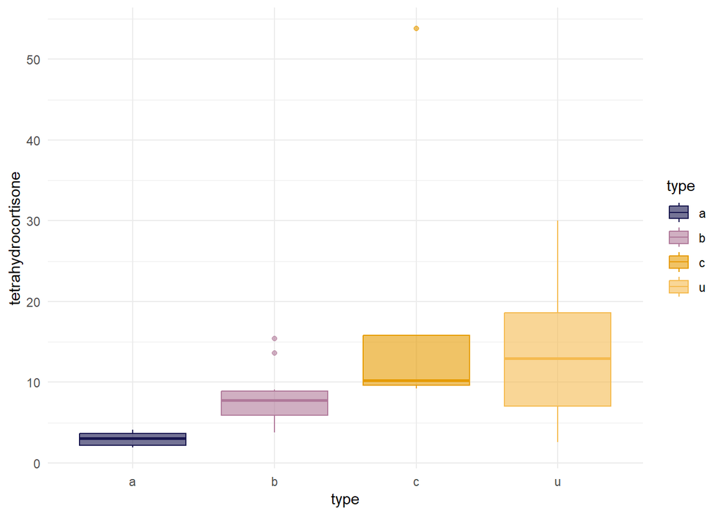

```r
ggplot(datos) +
  geom_boxplot(aes(x = type, y = tetrahydrocortisone,
                   fill = type, color = type), alpha = 0.6) +
  MetBrewer::scale_color_met_d(palette_name = "Renoir") +
  MetBrewer::scale_fill_met_d(palette_name = "Renoir") +
  theme_minimal()
```